# 4. stars data model

Edzer Pebesma

**For a better version of the stars vignettes see** https://r-spatial.github.io/stars/articles/

This vignette explains the data model of `stars` objects, illustrated using artificial and real datasets.

## Stars objects

`stars` objects consist of

- a (possibly empty) named list of arrays, each having named dimensions (`dim`) attribute
- an attribute called `dimensions` of class `dimensions` that carries dimension metadata
- a class name that includes `stars`

- `dimensions` length 2 character; the dimension names that constitute a spatial raster (or NA)
- `affine` length 2 numeric; the two affine parameters of the geotransform (or NA)
- `curvilinear` a boolean indicating whether a raster is a curvilinear raster (or NA)

The `affine` and `curvilinear` values are only relevant in case of raster data, indicated by `dimensions` to have non-NA values.

A `dimension` object describes a *single* dimension; it is a list with named elements

- `from`: (numeric length 1): the start index of the array
- `to`: (numeric length 1): the end index of the array
- `offset`: (numeric length 1): the start coordinate (or time) value of the first pixel (i.e., a pixel/cell boundary)
- `delta`: (numeric length 1): the increment, or cell size
- `refsys`: (character, or `crs`): object describing the reference system; e.g. the PROJ string, or string `POSIXct` or `PCICt` (for 360 and 365 days/year calendars), or object of class `crs` (containing both EPSG code and proj4string)
- `point`: (logical length 1): boolean indicating whether cells/pixels refer to areas/periods, or to points/instances (may be NA)
- `values`: one of
  - `NULL` (missing),
  - a vector with coordinate values (numeric, `POSIXct`, `PCICt`, or `sfc`),
  - an object of class `intervals` (a list with two vectors, `start` and `end`, with interval start- and end-values), or
  - a matrix with longitudes or latitudes for all cells (in case of curvilinear grids)

`from` and `to` will usually be 1 and the dimension size, but `from` may be larger than 1 in case a sub-grid got was selected (or cropped).

`offset` and `delta` only apply to *regularly* discretized dimensions, and are `NA` if this is not the case. If they are `NA`, dimension values may be held in the `values` field. Rectilinear and curvilinear grids need grid values in `values` that can be either:

- for rectilinear grids: irregularly *spaced* coordinate values, or coordinate *intervals* of irregular width (a rectilinear grid *can* have one dimension that is regular),
- for curvilinear grids: or a matrix with grid cell centre values for *all* row/col combinations (usually in longitude or latitude).

Alternatively, `values` can contains a set of spatial geometries encoded in an `sfc` vector (“list-column”), in which case we have a [vector data cube](https://r-spatial.org/r/2022/09/12/vdc.html).

## Grid type

### Regular grids

```r
suppressPackageStartupMessages(library(stars))
m = matrix(1:20, nrow = 5, ncol = 4)
dim(m) = c(x = 5, y = 4) # named dim
(s = st_as_stars(m))
## stars object with 2 dimensions and 1 attribute
## attribute(s):
##     Min. 1st Qu. Median Mean 3rd Qu. Max.
## A1     1    5.75   10.5 10.5   15.25   20
## dimension(s):
##   from to offset delta point x/y
## x    1  5      0     1 FALSE [x]
## y    1  4      0     1 FALSE [y]
```

we see that

- the rows (5) are mapped to the first dimension, the x-coordinate
- the columns (4) are mapped to the second dimension, the y-coordinate
- the `from` and `to` fields of each dimension define a range that corresponds to the array dimension:

```r
dim(s[[1]])
## x y
## 5 4
```

- offset and delta specify how increasing row and column index maps to x and y coordinate values respectively.

When we plot this object, using the `image` method for `stars` objects,

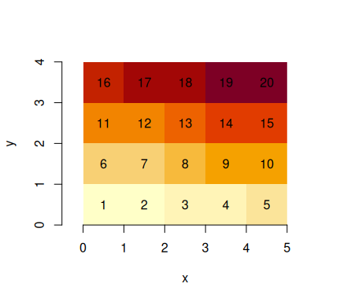

```r
image(s, text_values = TRUE, axes = TRUE)
```

we see that $(0,0)$ is the origin of the grid (grid corner), and $1$ the coordinate value increase from one index (row, col) to the next. It means that consecutive matrix columns represent grid lines, going from south to north. Grids defined this way are **regular**: grid cell size is constant everywhere.

Many actual grid datasets have y coordinates (grid rows) going from North to South (top to bottom); this is realised with a negative value for `delta`. We see that the grid origin $(0,0)$ did not change:

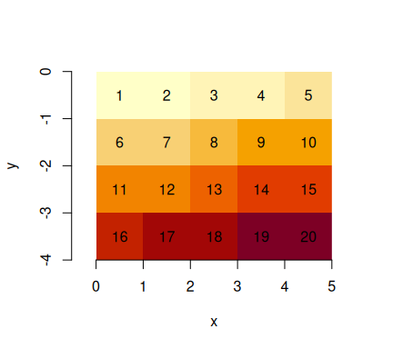

```r
attr(s, "dimensions")[[2]]$delta = -1
image(s, text_values = TRUE, axes = TRUE)
```

An example is the GeoTIFF carried in the package, which, as probably all data sources read through GDAL, has a negative `delta` for the `y`-coordinate:

```r
tif = system.file("tif/L7_ETMs.tif", package = "stars")
st_dimensions(read_stars(tif))["y"]
```

```
##   from  to  offset delta                     refsys point
## y    1 352 9120761 -28.5 SIRGAS 2000 / UTM zone 25S FALSE
```

### Raster attributes, rotated and sheared grids

Dimension tables of `stars` objects carry a `raster` attribute:

```r
str(attr(st_dimensions(s), "raster"))
```

```
## List of 4
##  $ affine     : num [1:2] 0 0
##  $ dimensions : chr [1:2] "x" "y"
##  $ curvilinear: logi FALSE
##  $ blocksizes : NULL
##  - attr(*, "class")= chr "stars_raster"
```

which is a list that holds

- `dimensions`: character, the names of raster dimensions (if any), as opposed to e.g. spectral, temporal or other dimensions
- `affine`: numeric, the affine parameters
- `curvilinear`: a logical indicating whether the raster is curvilinear

These fields are needed at this level, because they describe properties of the array at a higher level than individual dimensions do: a pair of dimensions forms a raster, both `affine` and `curvilinear` describe how x and y *as a pair* are derived from grid indexes (see below) when this cannot be done on a per-dimension basis.

With two affine parameters $a_1$ and $a_2$, $x$ and $y$ coordinates are derived from (1-based) grid indexes $i$ and $j$, grid offset values $o_x$ and $o_y$, and grid cell sizes $d_x$ and $d_y$ by

$$x = o_x + (i-1) d_x + (j-1)
a_1$$

$$y = o_y + (i-1) a_2 + (j-1) d_y$$
Clearly, when $a_1=a_2=0$, $x$ and $y$ are entirely derived from their respective index, offset and cellsize.

Note that for integer indexes, the coordinates are that of the starting edge of a grid cell; to get the grid cell center of the top left grid cell (in case of a negative $d_y$), use $i=1.5$ and $j=1.5$.

We can rotate grids by setting $a_1$ and $a_2$ to a non-zero value:

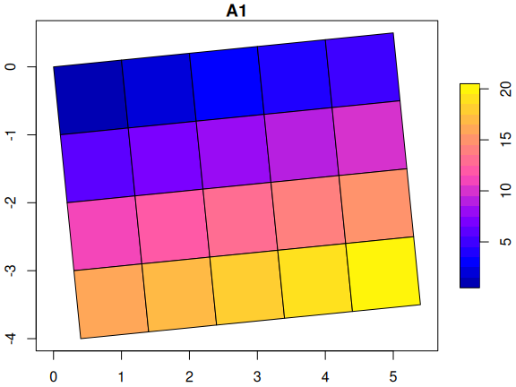

```r
attr(attr(s, "dimensions"), "raster")$affine = c(0.1, 0.1)
plot(st_as_sf(s, as_points = FALSE), axes = TRUE, nbreaks = 20)
```

The rotation angle, in degrees, is

```r
atan2(0.1, 1) * 180 / pi
```

```
## [1] 5.710593
```

Sheared grids are obtained when the two rotation coefficients, $a_1$ and $a_2$, are unequal:

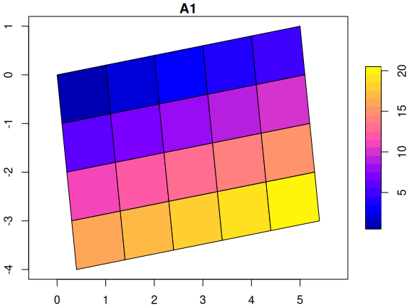

```r
attr(attr(s, "dimensions"), "raster")$affine = c(0.1, 0.2)
plot(st_as_sf(s, as_points = FALSE), axes = TRUE, nbreaks = 20)
```

Now, the y-axis and x-axis have different rotation in degrees of respectively

```r
atan2(c(0.1, 0.2), 1) * 180 / pi
```

```
## [1]  5.710593 11.309932
```

## Rectilinear grids

[Rectilinear grids](https://en.wikipedia.org/wiki/Regular_grid) have orthogonal axes, but do not have congruent (equally sized and shaped) cells: each axis has its own irregular subdivision.

We can define a rectilinear grid by specifying the cell *boundaries*, meaning for every dimension we specify *one more* value than the dimension size:

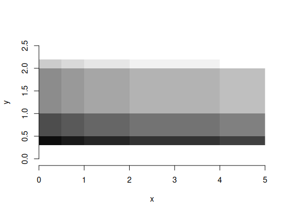

```r
x = c(0, 0.5, 1, 2, 4, 5)  # 6 numbers: boundaries!
y = c(0.3, 0.5, 1, 2, 2.2) # 5 numbers: boundaries!
(r = st_as_stars(list(m = m), dimensions = st_dimensions(x = x, y = y)))
## stars object with 2 dimensions and 1 attribute
## attribute(s):
##    Min. 1st Qu. Median Mean 3rd Qu. Max.
## m     1    5.75   10.5 10.5   15.25   20
## dimension(s):
##   from to point                values x/y
## x    1  5 FALSE     [0,0.5),...,[4,5) [x]
## y    1  4 FALSE [0.3,0.5),...,[2,2.2) [y]
st_bbox(r)
## xmin ymin xmax ymax
##  0.0  0.3  5.0  2.2
image(r, axes = TRUE, col = grey((1:20)/20))
```

Would we leave out the last value, than `stars` may come up with a *different* cell boundary for the last cell, as this is now derived from the width of the one-but-last cell:

```r
x = c(0, 0.5, 1, 2, 4)  # 5 numbers: offsets only!
y = c(0.3, 0.5, 1, 2)   # 4 numbers: offsets only!
(r = st_as_stars(list(m = m), dimensions = st_dimensions(x = x, y = y)))
## stars object with 2 dimensions and 1 attribute
## attribute(s):
##    Min. 1st Qu. Median Mean 3rd Qu. Max.
## m     1    5.75   10.5 10.5   15.25   20
## dimension(s):
##   from to point              values x/y
## x    1  5 FALSE   [0,0.5),...,[4,6) [x]
## y    1  4 FALSE [0.3,0.5),...,[2,3) [y]
st_bbox(r)
## xmin ymin xmax ymax
##  0.0  0.3  6.0  3.0
```

This is not problematic if cells have a constant width, in which case the boundaries are reduced to an `offset` and `delta` value, irrespective whether an upper boundary is given:

```r
x = c(0, 1, 2, 3, 4)  # 5 numbers: offsets only!
y = c(0.5, 1, 1.5, 2)   # 4 numbers: offsets only!
(r = st_as_stars(list(m = m), dimensions = st_dimensions(x = x, y = y)))
## stars object with 2 dimensions and 1 attribute
## attribute(s):
##    Min. 1st Qu. Median Mean 3rd Qu. Max.
## m     1    5.75   10.5 10.5   15.25   20
## dimension(s):
##   from to offset delta point x/y
## x    1  5      0     1 FALSE [x]
## y    1  4    0.5   0.5 FALSE [y]
st_bbox(r)
## xmin ymin xmax ymax
##  0.0  0.5  5.0  2.5
```

Alternatively, one can also set the *cell midpoints* by specifying arguments `cell_midpoints` to the `st_dimensions` call:

```r
x = st_as_stars(matrix(1:9, 3, 3),
                st_dimensions(x = c(1, 2, 3), y = c(2, 3, 10), cell_midpoints = TRUE))
```

When the dimension is regular, this results in `offset` being shifted back with half a `delta`, or else in intervals derived from the distances between cell centers. This should obviously not be done when cell boundaries are specified.

## Curvilinear grids

Curvilinear grids are grids whose grid lines are not straight. Rather than describing the curvature parametrically, the typical (HDF5 or NetCDF) files in which they are found have two raster layers with the longitudes and latitudes for every corresponding pixel of remaining layers.

As an example, we will use a Sentinel 5P dataset available from package `starsdata`; this package can be installed with

```r
install.packages("starsdata", repos = "https://cran.uni-muenster.de/pebesma/")
```

The dataset is found here:

```r
(s5p = system.file("sentinel5p/S5P_NRTI_L2__NO2____20180717T120113_20180717T120613_03932_01_010002_20180717T125231.nc", package = "starsdata"))
```

```
## [1] "/home/edzer/R/x86_64-pc-linux-gnu-library/4.4/starsdata/sentinel5p/S5P_NRTI_L2__NO2____20180717T120113_20180717T120613_03932_01_010002_20180717T125231.nc"
```

We can construct the curvilinear `stars` raster by calling `read_stars` on the right sub-array:

```r
subs = gdal_subdatasets(s5p)
subs[[6]]
```

```
## [1] "NETCDF:\"/home/edzer/R/x86_64-pc-linux-gnu-library/4.4/starsdata/sentinel5p/S5P_NRTI_L2__NO2____20180717T120113_20180717T120613_03932_01_010002_20180717T125231.nc\":/PRODUCT/nitrogendioxide_tropospheric_column"
```

For this array, we can see the GDAL metadata under item `GEOLOCATION`:

```r
gdal_metadata(subs[[6]], "GEOLOCATION")
```

```
## $SRS
## [1] "GEOGCS[\"WGS 84\",DATUM[\"WGS_1984\",SPHEROID[\"WGS 84\",6378137,298.257223563,AUTHORITY[\"EPSG\",\"7030\"]],AUTHORITY[\"EPSG\",\"6326\"]],PRIMEM[\"Greenwich\",0,AUTHORITY[\"EPSG\",\"8901\"]],UNIT[\"degree\",0.0174532925199433,AUTHORITY[\"EPSG\",\"9122\"]],AXIS[\"Latitude\",NORTH],AXIS[\"Lon…
##
## $X_DATASET
## [1] "NETCDF:\"/home/edzer/R/x86_64-pc-linux-gnu-library/4.4/starsdata/sentinel5p/S5P_NRTI_L2__NO2____20180717T120113_20180717T120613_03932_01_010002_20180717T125231.nc\":/PRODUCT/longitude"
##
## $X_BAND
## [1] "1"
##
## $Y_DATASET
## [1] "NETCDF:\"/home/edzer/R/x86_64-pc-linux-gnu-library/4.4/starsdata/sentinel5p/S5P_NRTI_L2__NO2____20180717T120113_20180717T120613_03932_01_010002_20180717T125231.nc\":/PRODUCT/latitude"
##
## $Y_BAND
## [1] "1"
##
## $PIXEL_OFFSET
## [1] "0"
##
## $PIXEL_STEP
## [1] "1"
##
## $LINE_OFFSET
## [1] "0"
##
## $LINE_STEP
## [1] "1"
##
## $GEOREFERENCING_CONVENTION
## [1] "PIXEL_CENTER"
##
## attr(,"class")
## [1] "gdal_metadata"
```

which reveals where, in this dataset, the longitude and latitude arrays are kept.

```r
nit.c = read_stars(subs[[6]])
```

[output not shown]

```r
threshold = units::set_units(9e+36, mol/m^2)
nit.c[[1]][nit.c[[1]] > threshold] = NA
nit.c
## stars object with 3 dimensions and 1 attribute
## attribute(s):
##                                                   Min.      1st Qu.
## nitrogendioxide_tropospheri... [mol/m^2] -3.301083e-05 1.868205e-05
##                                                Median         Mean      3rd Qu.
## nitrogendioxide_tropospheri... [mol/m^2] 2.622178e-05 2.898976e-05 3.629641e-05
##                                                  Max. NA's
## nitrogendioxide_tropospheri... [mol/m^2] 0.0003924858  330
## dimension(s):
##      from  to         offset         refsys                             values
## x       1 450             NA WGS 84 (CRS84) [450x278] -5.811 [°],...,30.95 [°]
## y       1 278             NA WGS 84 (CRS84)  [450x278] 28.36 [°],...,51.47 [°]
## time    1   1 2018-07-17 UTC        POSIXct                               NULL
##      x/y
## x    [x]
## y    [y]
## time
## curvilinear grid
```

The curvilinear array has the actual arrays (raster layers, matrices) with longitude and latitude values read in its dimension table. We can plot this file:

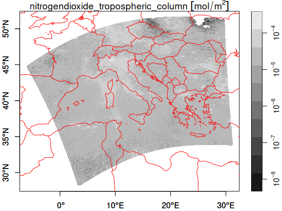

```r
plot(nit.c, breaks = "equal", reset = FALSE, axes = TRUE, as_points = TRUE,
         pch = 16,  logz = TRUE, key.length = 1)
maps::map('world', add = TRUE, col = 'red')
```

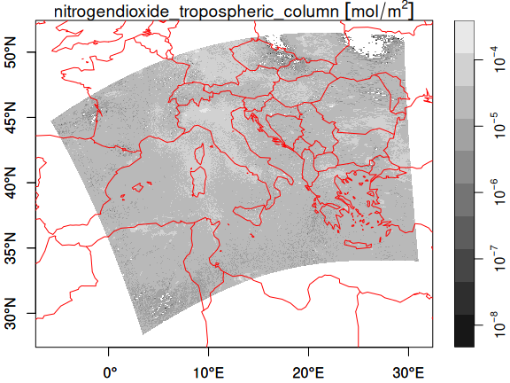

```r
plot(nit.c, breaks = "equal", reset = FALSE, axes = TRUE, as_points = FALSE,
         border = NA, logz = TRUE, key.length = 1)
maps::map('world', add = TRUE, col = 'red')
```

We can downsample the data by

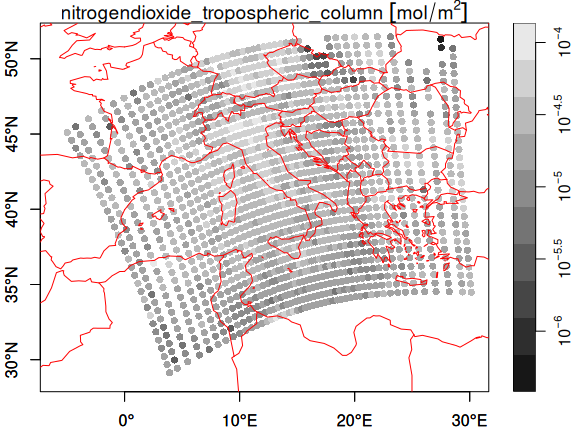

```r
(nit.c_ds = stars:::st_downsample(nit.c, 8))
## stars object with 3 dimensions and 1 attribute
## attribute(s):
##                                                   Min.     1st Qu.       Median
## nitrogendioxide_tropospheri... [mol/m^2] -1.847503e-05 1.85778e-05 2.700901e-05
##                                                Mean      3rd Qu.         Max.
## nitrogendioxide_tropospheri... [mol/m^2] 2.9113e-05 3.642568e-05 0.0001363282
##                                          NA's
## nitrogendioxide_tropospheri... [mol/m^2]   32
## dimension(s):
##      from to         offset         refsys                           values x/y
## x       1 50             NA WGS 84 (CRS84) [50x31] -5.811 [°],...,30.14 [°] [x]
## y       1 31             NA WGS 84 (CRS84)  [50x31] 28.78 [°],...,51.47 [°] [y]
## time    1  1 2018-07-17 UTC        POSIXct                             NULL
## curvilinear grid
plot(nit.c_ds, breaks = "equal", reset = FALSE, axes = TRUE, as_points = TRUE,
         pch = 16, logz = TRUE, key.length = 1)
maps::map('world', add = TRUE, col = 'red')
```

which doesn’t look nice, but plotting the cells as polygons looks better:

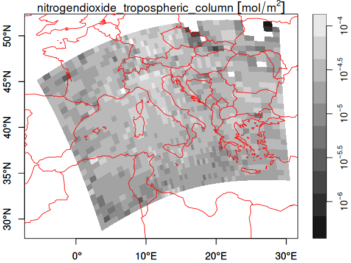

```r
plot(nit.c_ds, breaks = "equal", reset = FALSE, axes = TRUE, as_points = FALSE,
         border = NA, logz = TRUE, key.length = 1)
maps::map('world', add = TRUE, col = 'red')
```

Another approach would be to warp the curvilinear grid to a regular grid, e.g. by

```r
w = st_warp(nit.c, crs = 4326, cellsize = 0.25)
```

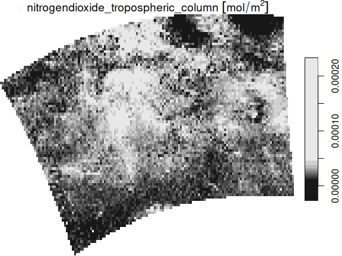

```r
plot(w)
```